# exercise-09

Matt Ming

3/24/2022

## Exercise

Load in another dataset

```r
library(tidyverse)
library(broom)
library(manipulate)
library(patchwork)
library(infer)
f <- "https://raw.githubusercontent.com/difiore/ada-2022-datasets/main/Street_et_al_2017.csv"
d <- read_csv(f, col_names = TRUE)
head(d)
```

```
## # A tibble: 6 x 13
##   Species       Taxonomic_group Social_learning Research_effort   ECV Group_size
##   <chr>         <chr>                     <dbl>           <dbl> <dbl>      <dbl>
## 1 Allenopithec~ Catarrhini                    0               6  58.0       40
## 2 Allocebus_tr~ Catarrhini                    0               6  NA          1
## 3 Alouatta_bel~ Platyrrhini                   0              15  52.8        7.4
## 4 Alouatta_car~ Platyrrhini                   0              45  52.6        8.9
## 5 Alouatta_gua~ Platyrrhini                   0              37  51.7        7.4
## 6 Alouatta_pal~ Platyrrhini                   3              79  49.9       13.1
## # ... with 7 more variables: Gestation <dbl>, Weaning <dbl>, Longevity <dbl>,
## #   Sex_maturity <dbl>, Body_mass <dbl>, Maternal_investment <dbl>,
## #   Repro_lifespan <dbl>
```

We can quickly get a sense of the data by finding the min, mean, median, max, Q1 and Q3.

```r
for(i in 3:length(names(d))){
  sdi <- sd(d[[i]],na.rm = TRUE)
  cat(names(d)[i],"\n")
  cat(summary(d[,i])[c(1,2,3,5,6),1],sep = "\n")
  cat(summary(d[,i])[4,1])
  cat("\nSD     :",sdi,sep = "")
  cat("\n\n")
}
```

```
## Social_learning
## Min.   :  0.0
## 1st Qu.:  0.0
## Median :  0.0
## 3rd Qu.:  0.0
## Max.   :214.0
## Mean   :  2.3
## SD     :16.51382
##
## Research_effort
## Min.   :  1.00
## 1st Qu.:  6.00
## Median : 16.00
## 3rd Qu.: 37.75
## Max.   :755.00
## Mean   : 38.76
## SD     :80.58897
##
## ECV
## Min.   :  1.63
## 1st Qu.: 11.82
## Median : 58.55
## 3rd Qu.: 86.20
## Max.   :491.27
## Mean   : 68.49
## SD     :82.84154
##
## Group_size
## Min.   : 1.000
## 1st Qu.: 3.125
## Median : 7.500
## 3rd Qu.:18.225
## Max.   :91.200
## Mean   :13.263
## SD     :15.19637
##
## Gestation
## Min.   : 59.99
## 1st Qu.:138.35
## Median :166.03
```

[output cut: 43 more lines]

```
## 1st Qu.: 255.88
## Median : 401.35
## 3rd Qu.: 592.22
## Max.   :1492.30
## Mean   : 478.64
## SD     :292.0681
##
## Repro_lifespan
## Min.   : 2512
## 1st Qu.: 6126
## Median : 8326
## 3rd Qu.:10717
## Max.   :39130
## Mean   : 9065
## SD     :4601.568
```

To get plots for ECV vs each of “Group_size”, “Longevity”, “Weaning”, and “Repro_lifespan”, I first convert the table from “wide” to “long”, meaning that each column name will now be stored as a variable. I can then use facet wrap to plot these variables side by side

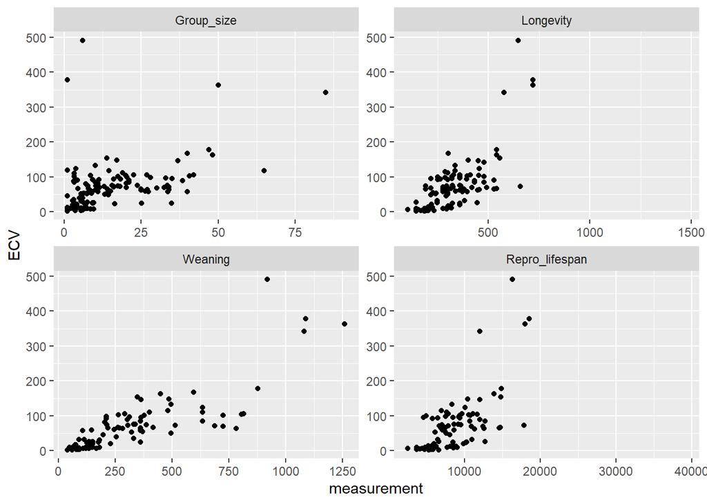

```r
dlong <- d %>% select(ECV,Group_size,Longevity,Weaning,Repro_lifespan) %>%
  gather(variable,measurement,
         Group_size,Longevity,Weaning,Repro_lifespan,
         factor_key = TRUE)
p <- ggplot(dlong,aes(measurement,ECV)) + geom_point() +
  facet_wrap(~variable,scales = "free")
print(p)
```

We’ll now zoom in on just ECV vs. Groupsize and compute regression on just these two variables

```r
d2 <- d %>% select(ECV,Group_size) %>% drop_na()
head(d2)
```

```
## # A tibble: 6 x 2
##     ECV Group_size
##   <dbl>      <dbl>
## 1  58.0       40
## 2  52.8        7.4
## 3  52.6        8.9
## 4  51.7        7.4
## 5  49.9       13.1
## 6  51.1        5.5
```

We can plot brain size (ECV) vs Social Group Size

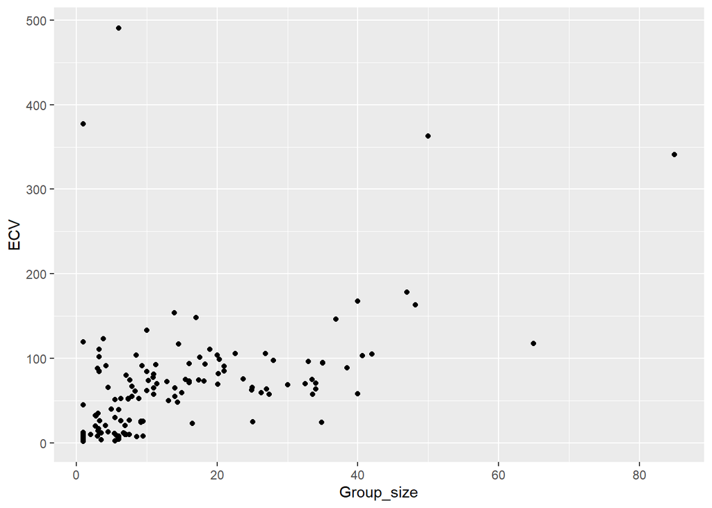

```r
ggplot(data = d2,aes(Group_size,ECV)) + geom_point()
```

We now want to derive by hand the ordinary least squares regression coefficients $\beta_1$ and $\beta_0$ for ECV ~ Social Group Size

```r
b1 <- cor(d2$Group_size,d2$ECV)*sd(d2$ECV)/sd(d2$Group_size)
cat("beta_1 =",b1)
```

```
## beta_1 = 2.463071
```

```r
b0 <- mean(d2$ECV) - b1*mean(d2$Group_size)
cat("\nbeta_0 =",b0)
```

```
##
## beta_0 = 30.35652
```

We can confirm these results using the lm() function and looking at the coefficients

```r
r <- lm(ECV ~ Group_size,data = d2)
summary(r)
```

```
##
## Call:
## lm(formula = ECV ~ Group_size, data = d2)
##
## Residuals:
##    Min     1Q Median     3Q    Max
## -92.05 -29.25 -15.14  13.07 445.28
##
## Coefficients:
##             Estimate Std. Error t value Pr(>|t|)
## (Intercept)  30.3565     6.7963   4.467 1.56e-05 ***
## Group_size    2.4631     0.3508   7.021 7.26e-11 ***
## ---
## Signif. codes:  0 '***' 0.001 '**' 0.01 '*' 0.05 '.' 0.1 ' ' 1
##
## Residual standard error: 60.31 on 149 degrees of freedom
## Multiple R-squared:  0.2486, Adjusted R-squared:  0.2436
## F-statistic:  49.3 on 1 and 149 DF,  p-value: 7.259e-11
```

This reconfirms that the coefficients $\beta_1 = 2.463$ and $\beta_0 = 30.357$

We now perform this above analysis for each of the three main taxonomic groups: catarrhines, platyrrhines, and strepsirhines.

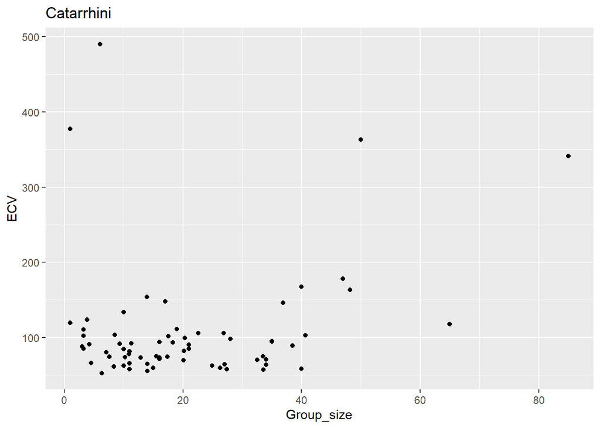

```
##
##
## Primate Group: Catarrhini
## beta_1 = 1.146322
## beta_0 = 83.42059
```

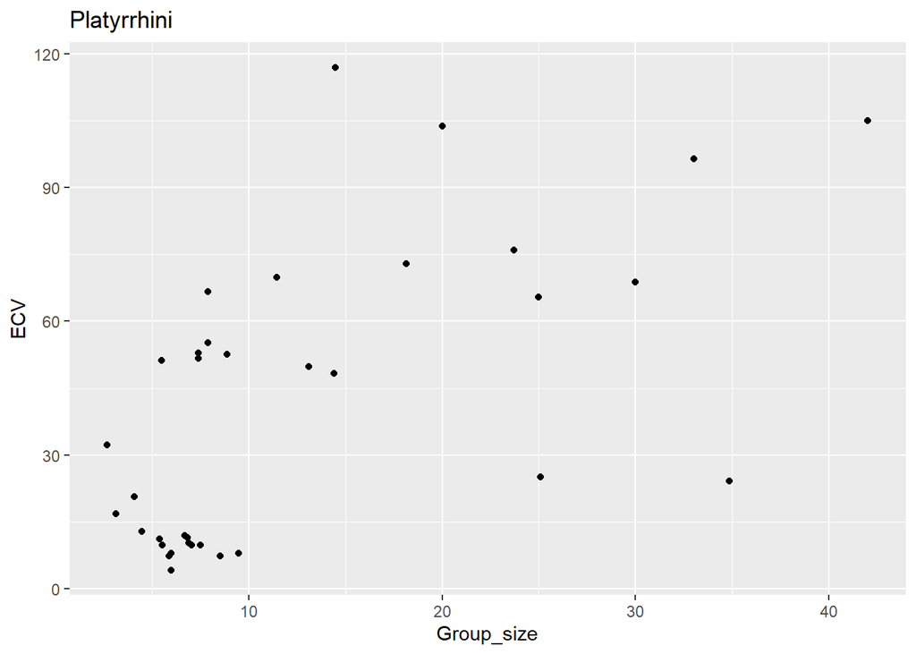

```
##
##
## Primate Group: Platyrrhini
## beta_1 = 1.965176
## beta_0 = 16.18121
```

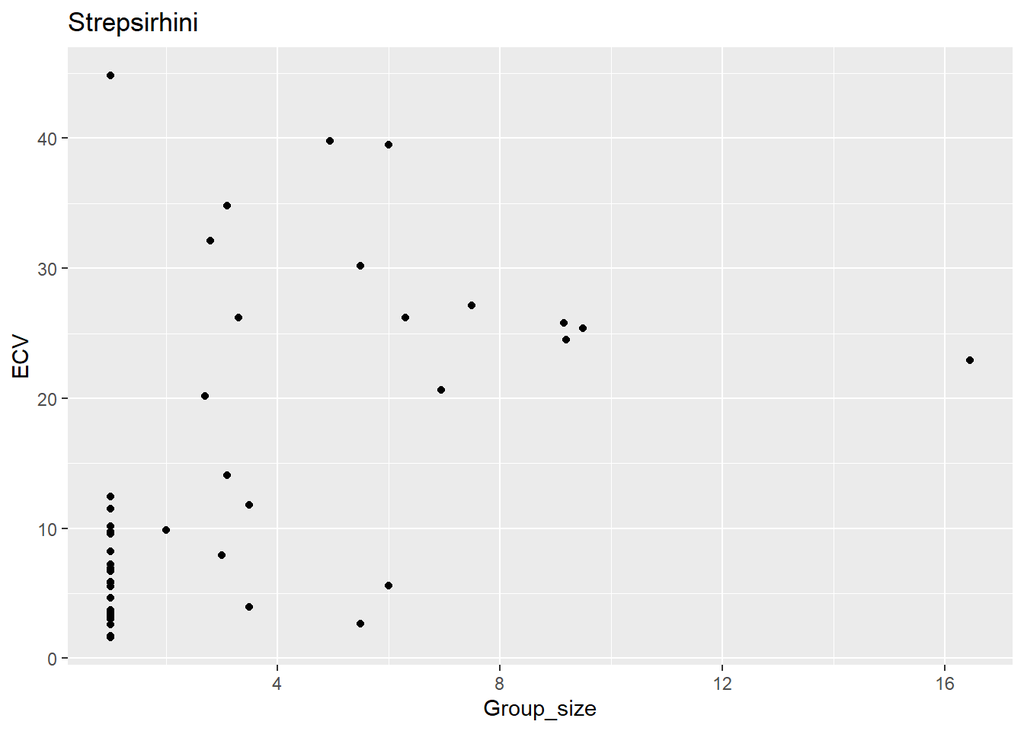

```
##
##
## Primate Group: Strepsirhini
## beta_1 = 1.840664
## beta_0 = 8.176384
```

```r
for(group in unique(d$Taxonomic_group)){
  d3 <- d %>% filter(Taxonomic_group == group) %>% select(ECV,Group_size) %>%
    drop_na()
  print(ggplot(data = d3,aes(Group_size,ECV)) + geom_point() + ggtitle(group))
  b1group <- cor(d3$Group_size,d3$ECV)*sd(d3$ECV)/sd(d3$Group_size)
  cat("\n\nPrimate Group:",group)
  cat("\nbeta_1 =",b1group)
  b0group <- mean(d3$ECV) - b1group*mean(d3$Group_size)
  cat("\nbeta_0 =",b0group)
  rgroup <- lm(ECV ~ Group_size,data = d3)
  summary(rgroup)
}
```

A visual comparison of the values of the slope coefficients shows that the platyrrhine and strepsirhine groups have higher slope coefficients than the catarrhine group, but and that those two groups have closer slope coeffeicients than either is to catarrhines. In order to really test for significance between these groups, we could use a t-test between these groups.

We now want to calculate by hand a Standard Error for our estimates of $\beta_1$

This follows $S_{\hat{\beta}_1}$ = $\sqrt{\frac{\Sigma_i {\hat{\epsilon}_i}^2}{(n-2) \Sigma_i (x_i - \bar{x})^2}}$

```r
# Get a vector of residuals for ECV as a function of Group_Size
ei <- d2$ECV - (d2$Group_size * b1 + b0)

# Get the calculation for SE of B_1
n <- length(d2$Group_size)
x <- d2$Group_size
sb1 <- sqrt((sum((ei)^2))/((n-2) * sum((x - mean(x))^2)))

cat("SE of beta_1 (slope) =",sb1)
```

```
## SE of beta_1 (slope) = 0.3508061
```

Doing this SE calculation by hand we find $S_{\hat{\beta}_1} = 0.3508061$, which is also reconfirmed by the summary of the lm() function.

```r
CI <- b1 + c(-1,1)*qt(1-0.025,df = n-2)*sb1
cat("Lower CI\tUpper CI\n")
```

```
## Lower CI Upper CI
```

```r
cat(CI,sep = "\t")
```

```
## 1.769874 3.156269
```

Now, in order to get the p-value associated with the $\beta_1$ value we got, I can find a t-value for $\beta_1$ by dividing $\hat{\beta}_1/S_{\hat{\beta}_1}$. Doing this gives us

```r
t <- b1/sb1
cat("The t-statistic for beta_1 =",t)
```

```
## The t-statistic for beta_1 = 7.021176
```

```r
p <- pt(abs(t),df = n-2,lower.tail = FALSE)*2
cat(" which has a p-value of",p)
```

```
##  which has a p-value of 7.259435e-11
```

```r
if(p <= 0.001){cat("***")
}else if(p <= 0.01){cat("**")
}else if(p <= 0.05){cat("*")}
```

Next, we want to use a permutation approach to generate a null sampling distribution of the slope coefficient. In this case, the null hypothesis is that there is no relationship between ECV and Group Size, or in other words that the slope of a regression line between these variables is zero. By permuting one of the columns for these variables, we’re breaking the association between them and creating a distribution which should be centered around the null of 0.

We can permute either of the variables (ECV or Group Size) and I have arbitrarily chosen to permute Group Size.

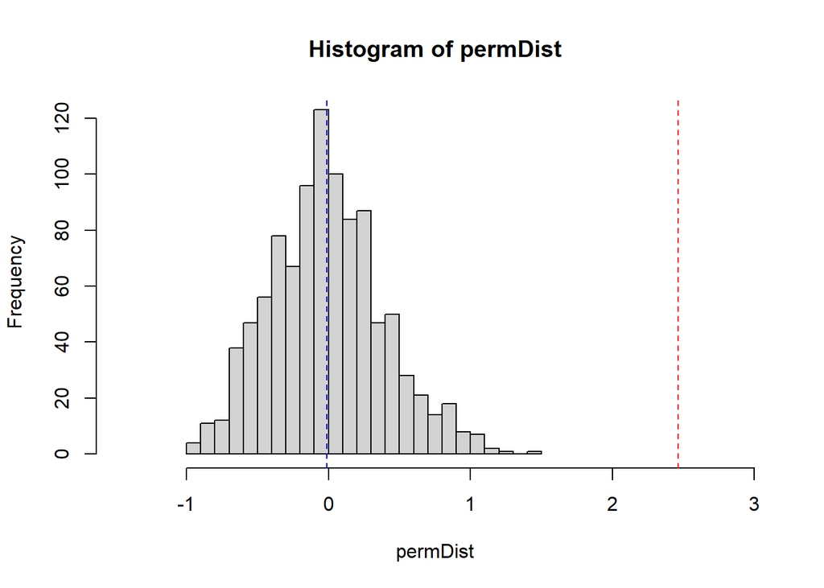

```r
set.seed(123)
permDist <- rep(NA,1000)
for(i in 1:1000){
  d3 <- d2
  d3$Group_size <- sample(d3$Group_size)
  B1_i <- lm(ECV ~ Group_size,data = d3)$coefficients[2]
  permDist[i] <- B1_i
}
hist(permDist,breaks = 30,
     xlim = c(min(min(permDist),b1)-0.5,max(max(permDist),b1)+0.5))
abline(v = b1,col = "red",lty = "dashed")
abline(v = mean(permDist),col = "blue",lty = "dashed")
```

```r
p_perm <- (sum(permDist >= abs(b1)) + sum(permDist <= -abs(b1)))/
  length(permDist)
cat("The empirical permutation p-value is",p_perm)
```

```
## The empirical permutation p-value is 0
```

```r
if(p_perm <= 0.001){cat("***")
}else if(p_perm <= 0.01){cat("**")
}else if(p_perm <= 0.05){cat("*")}
```

```r
p_perm2 <- pnorm(b1,mean = mean(permDist),sd = sd(permDist),lower.tail = FALSE)
cat("\n\nThe theoretical p-value based on a normal curve centered around the",
    "permuted null distribution is",p_perm2)
```

```
##
##
## The theoretical p-value based on a normal curve centered around the permuted null distribution is 2.457009e-10
```

```r
if(p_perm2 <= 0.001){cat("***")
}else if(p_perm2 <= 0.01){cat("**")
}else if(p_perm2 <= 0.05){cat("*")}
```

Finally, we want set up a bootstrap distribution by randomly re-sampling (with replacement) from the original data set of paired observations of ECV and Group Size. In this way we can get an estimated sampling distribution around our estimate of the slope of the regression line. From this we get a 95% confidence interval around our estimate by using the 0.025 and 0.975 quantiles.

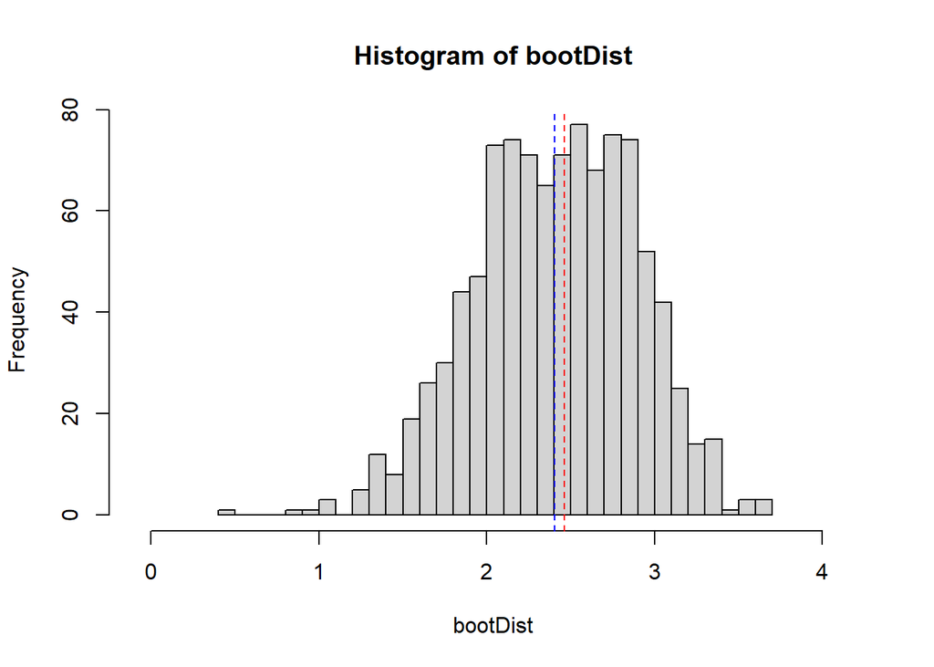

```r
set.seed(123)
bootDist <- rep(NA,1000)
for(i in 1:1000){
  bootsamps <- sample(1:length(d2$ECV),replace = TRUE)
  d4 <- data.frame(ECV = d2$ECV[bootsamps],
                   Group_size = d2$Group_size[bootsamps])
  B1_i <- lm(ECV ~ Group_size,data = d4)$coefficients[2]
  bootDist[i] <- B1_i
}
hist(bootDist,breaks = 30,
     xlim = c(min(min(bootDist),b1)-0.5,max(max(bootDist),b1)+0.5))
abline(v = b1,col = "red",lty = "dashed")
abline(v = mean(bootDist),col = "blue",lty = "dashed")
```

```r
cat("A 95% confidence interval around the estimate of slope using the bootstrap",
    "distribution is",
    quantile(bootDist,0.025),"to",quantile(bootDist,0.975))
```

```
## A 95% confidence interval around the estimate of slope using the bootstrap distribution is 1.40735 to 3.270864
```

```r
cat("\n\nA 95% confidence interval around the estimate of slope uing a normal",
    "distribution based on our bootstrap distribution is",
    qnorm(0.025,mean = mean(bootDist),sd = sd(bootDist)),"to",
    qnorm(0.975,mean = mean(bootDist),sd = sd(bootDist)))
```

```
##
##
## A 95% confidence interval around the estimate of slope uing a normal distribution based on our bootstrap distribution is 1.463982 to 3.346586
```

```r
p_boot <- (sum(-bootDist >= 0) + sum(bootDist <= 0))/
  length(bootDist)
cat("\n\nThe empirical bootstrap p-value is",p_boot)
```

```
##
##
## The empirical bootstrap p-value is 0
```

```r
if(p_boot <= 0.001){cat("***")
}else if(p_boot <= 0.01){cat("**")
}else if(p_boot <= 0.05){cat("*")}
```

```r
p_boot2 <- pnorm(0,mean = mean(bootDist),sd = sd(bootDist))
cat("\n\nThe theoretical p-value based on a normal curve centered around the",
    "bootstrap distribution is",p_boot2)
```

```
##
##
## The theoretical p-value based on a normal curve centered around the bootstrap distribution is 2.746429e-07
```

```r
if(p_boot2 <= 0.001){cat("***")
}else if(p_boot2 <= 0.01){cat("**")
}else if(p_boot2 <= 0.05){cat("*")}
```